# Examining Pregnancy Prevention Methods among Adolescents AFAB

BMIN503/EPID600 Final Project

Author

Gabrielle Zuckerman

## 1 Overview

Preventing unintended teenage pregnancy is a public health priority that can be mitigated by individual uptake of effective contraception in sexually active teens. The Centers for Disease Control and Prevention publishes a publicly available dataset called the National High School Youth Risk Behavior Survey (YRBS) that contains information on important health behaviors and experiences in American high school students. Thus, the goal of this project is to use data from the YRBS to see what proportion of sexually active adolescents that were assigned female at birth (AFAB) utilize pregnancy prevention methods, which pregnancy methods are most popular among them, and whether these outcomes vary by sexual minority status.

## 2 Introduction

Despite decreases over the past several decades, unintended teenage pregnancy continues to persist as a public health problem that, compared to other high income countries, is especially prevalent in the United States.<sup>1</sup> One objective of Healthy People 2030, an initiative from the US Department of Health and Human Services that identifies public health priorities to improve health and well-being across the United States,<sup>2</sup> is to “increase the proportion of adolescent females who used effective birth control the last time they had sex.”<sup>3</sup> In fact, several Healthy People 2030 objectives are related to adolescent sexual education, behaviors, and outcomes.<sup>4</sup> There has also been extensive evidence demonstrating that teen pregnancy has negative lifelong consequences for both the birthing parent and the child.<sup>5</sup> Teen pregnancy is also a health disparities issue. Disparities have been observed by age, race, geography, and socioeconomic status.<sup>6</sup> Moreover, prior work has found that sexual minority adolescents are at a greater risk of teenage pregnancy than their heterosexual peers.<sup>7–10</sup> This justifies an examination of contraceptive use by sociodemographic factors.

Addressing and acquiring knowledge about adolescent contraceptive use requires an interdisciplinary approach. In addition to thinking about unintended pregnancy as a public health issue, behavioral experts (e.g., psychologists, health behaviorists) can contribute to our understanding of which adolescents choose to use contraception methods and what characteristics they express. Additionally, contraceptive access is of concern as adolescents may not have the financial or transportational means to ascertain pregnancy prevention and/or can lack health literacy around this sexual health. Lastly, because sex is particularly stigmatized among adolescents, teens cannot necessarily rely on their guardians or medical providers for sex-related advice or assistance in utilizing contraception.

## 3 Methods

### 3.1 Load Necessary Packages

We will first load several packages that will be used to analyze the YRBS data.

```r
library(tidyverse)
library(ggthemes)
library(png)
library(Hmisc)
library(survey)
library(table1)
library(gtsummary)
library(expss)
library(ggsurvey)
```

### 3.2 Data Overview

This project utilizes data from the 2021 National High School Youth Risk Behavior Survey (YRBS). Years prior to 2015 did not collect information on sexual orientation. While sexual orientation was collected in 2015-2019 (“Which of the following best describes you?”), years prior to 2021 only offered the following response options: “heterosexual (straight),” “gay or lesbian,” “bisexual,” and “not sure.” In order to capture adolescents whose self-describe their sexual orientation as”questioning” or “other,” only 2021 data were used. Accurately capturing sexual orientation is of import as one of the primary project aims is to investigate whether use and type of pregnancy prevention methods differs by sexual minority status.

### 3.3 Data Import

YRBS does not have data in CSV form (only .dat files were available), so the dataset had to be downloaded and opened in SAS. Additionally, YRBS provides SAS code for loading and formatting the data. Thus, the data is already properly labelled and formatted. I additionally filtered out data from years outside of 2015-2021. No other data cleaning was conducted prior to running the following code.

```r
yrbs <- read.csv("/Users/gmzuck/Library/Mobile Documents/com~apple~CloudDocs/Desktop/UPenn/Coursework/Fall 2023/EPID 6000/yrbs2015-2021.csv")
```

### 3.4 Data Cleaning

#### 3.4.1 Only include 2021 data, re-code missing values, exclude non-female students, and exclude variables not relevant to the project

Remove observations for any year that is not 2021.

```r
yrbs <- yrbs %>% filter(year==2021)
```

Missing values are currently coded as the string “Missing” and must be changed to NA.

```r
yrbs[yrbs=="Missing"] <- NA
```

We only want to include students who report that their sex is female.

```r
yrbs.female <- yrbs[yrbs$sex == "Female" & !is.na(yrbs$sex),]
```

Now, we will limit the dataset to only include variables of interest as there are currently >200 variables to look through in the dataset.

```r
yrbs.female <- yrbs.female %>% subset(select=c(year,weight,stratum,PSU,record,age,sex,grade,race4,race7,sexid,sexid2,q65,sexpart,sexpart2,q57,qn57,q58,qn58,q59,qn59,q60,qn60,q61,qn61,q62,qn62,q63,qn63,q64,q30,qn30,q34,qn34,q37,qn37,q38,qn38,q40,qn40,q45,qn45,q48,qn48,q49,qn49,q50,qn50,q51,qn51,q52,qn52,q53,qn53,q54,qn54,q55,qn55,q82,qn82,q83,qn83))
```

#### 3.4.2 Give labels to the variables in the dataset

We now want to give the variables labels so we can more easily identify them.

```r
yrbs.female = apply_labels(yrbs.female,
              year="Year of Survey",
               weight="Analytical Weight",
               stratum="Analytical Stratum",
               PSU="Analytical Primary Sampling Unit",
               record="ID",
               age="Age in Years",
               sex="Sex of the participant",
               grade="Grade",
               race4="4-level Race/Ethnicity",
               race7="7-level Race/Ethnicity",
               q65="Sexual Orientation Survey Item",
               sexid="Sexual Orientation",
               sexid2="Collapsed Sexual Orientation",
               q57="Have you had sexual intercourse?",
               qn57="Dichotomous: Have you had sexual intercourse?",
               sexpart="Sex of sexual contact(s)",
               sexpart2="Collapsed sex of sexual contact(s)",
               q58="How old were you when you had sexual intercourse for the first time?",
               qn58="Dichotomous: How old were you when you had sexual intercourse for the first time?",
               q59="During your life, with how many people have you had sexual intercourse?",
               qn59="Dichotomous: During your life, with how many people have you had sexual intercourse?",
               q60="During the past 3 months, with how many people did you have sexual intercourse?",
               qn60="Dichotomous: During the past 3 months, with how many people did you have sexual intercourse?",
               q61="Did you drink alcohol or use drugs before you had sexual intercourse the last time?",
               qn61="Dichotomous: Did you drink alcohol or use drugs before you had sexual intercourse the last time?",
               q62="The last time you had sexual intercourse, did you or your partner use a condom?",
               qn62="Dichotomous: The last time you had sexual intercourse, did you or your partner use a condom?",
               q63="The last time you had sexual intercourse with an opposite-sex partner, what one method did you or your partner use to prevent pregnancy?",
               qn63="Dichotomous: The last time you had sexual intercourse with an opposite-sex partner, what one method did you or your partner use to prevent pregnancy?",
               q64="During your life, with whom have you had sexual contact?",
               q30="Have you ever tried cigarette smoking, even one or two puffs?",
               qn30="Dichotomous: Ever tried cigarette smoking",
               q34="Have you ever used an electronic vapor product?",
               qn34="Dichotomous: Ever used an electronic vapor product",
               q37="# of days in the past month that you used chewing tobacco, snuff, dip, snus, or dissolvable tobacco products",
               qn37="Dichotomous: # of days in the past month that you used chewing tobacco, snuff, dip, snus, or dissolvable tobacco products",
               q38="During the past 30 days, on how many days did you smoke cigars, cigarillos, or little cigars?",
               qn38="Dichotomous: During the past 30 days, on how many days did you smoke cigars, cigarillos, or little cigars?",
               q40="How old were you when you had your first drink of alcohol other than a few sips?",
               qn40="Dichotomous: Age at first alcoholic drink",
               q45="During your life, how many times have you used marijuana?",
               qn45="Dichotomous: Lifetime marijuana use",
               q48="During your life, how many times have you used synthetic marijuana?",
               qn48="Dichotomous: Lifetime synthetic marijuana use",
               q49="During your life, how many times have you taken prescription pain medicine without a doctor's prescription or differently than how a doctor told you to use it?",
               qn49="Dichotomous: Lifetime prescription pain medicine abuse",
               q50="During your life, how many times have you used any form of cocaine, including powder, crack, or freebase?",
               qn50="Dichotomous: Lifetime cocaine use",
               q51="During your life, how many times have you sniffed glue, breathed the contents of aerosol spray cans, or inhaled any paints or sprays to get high?",
               qn51="Dichotomous: Lifetime inhalant use",
               q52="During your life, how many times have you used heroin (also called smack, junk, or China White)?",
               qn52="Dichotomous: Lifetime heroin use",
               q53="During your life, how many times have you used methamphetamines (also called speed, crystal meth, crank, ice, or meth)?",
               qn53="Dichotomous: Lifetime methamphetamines use",
               q54="During your life, how many times have you used ecstasy (also called MDMA or Molly)?",
               qn54="Dichotomous: Lifetime ecstasy use",
               q55="During your life, how many times have you used a needle to inject any illegal drug into your body?",
               qn55="Dichotomous: Lifetime intravenous illicit drug use",
               q82="Have you ever been tested for HIV, the virus that causes AIDS?",
               qn82="Dichotomous: Ever been tested for HIV",
               q83="During the past 12 months, have you been tested for a sexually transmitted disease (STD) other than HIV, such as chlamydia or gonorrhea? ",
               qn83="Dichotomous: STD test in the past year"
               )
```

#### 3.4.3 Limit the dataset to respondents who identify as heterosexual or a sexual minority

```r
yrbs.female <- yrbs.female[(yrbs.female$sexid2=="Heterosexual" | yrbs.female$sexid2=="Sexual Minority") & !is.na(yrbs.female$sexid2),]
```

#### 3.4.4 Changing variable classes to factor (as needed)

```r
# Sexual orientation
yrbs.female$sex.orientation <- ifelse(yrbs.female$sexid2=="Heterosexual", 1, 2)
yrbs.female$sex.orientation <- factor(yrbs.female$sex.orientation, levels=1:2,                                                      labels=c("Heterosexual", "Sexual Minority"))
# qn57 - Ever had sex
yrbs.female$qn57 <- factor(yrbs.female$qn57, levels=1:2, labels=c("Yes","No"))

# qn58 - Age at first time having sexual intercourse
yrbs.female$qn58 <- ifelse(
  yrbs.female$q58=="11 years old or younger" | yrbs.female$q58=="12 years old" | yrbs.female$q58=="13 years old", 1, ifelse(
    yrbs.female$q58=="14 years old" | yrbs.female$q58=="15 years old" | yrbs.female$q58=="16 years old" | yrbs.female$q58=="17 years old or older", 2, NA
  )
)
yrbs.female$qn58 <- factor(yrbs.female$qn58, levels=1:2, labels=c("<14 years old", "14+"))

# qn59 - # of lifetime sexual partners
yrbs.female$qn59 <- factor(yrbs.female$qn59, levels=1:2, labels=c("4+","0-3"))

# qn60 - # of sexual partners in past 3 months
yrbs.female$qn60 <- factor(yrbs.female$qn60, levels=1:2, labels=c("1+","0"))

# qn62 - Condom use during most recent sexual encounter
yrbs.female$qn62 <- ifelse(yrbs.female$qn62==1, 1,
                             ifelse(yrbs.female$qn62==2, 2, NA))
yrbs.female$qn62 <- factor(yrbs.female$qn62, levels=1:2, labels=c("Yes","No"))

# qn63 - Use of any pregnancy prevention method in most recent sexual encounter
yrbs.female$qn63 <- ifelse(
  yrbs.female$q63=="Birth control pills" | yrbs.female$q63=="Condoms" | yrbs.female$q63=="IUD or implant" | yrbs.female$q63=="Shot/patch/birth control ring" | yrbs.female$q63=="Withdrawal or something else", 1, ifelse(
    yrbs.female$q63=="No birth control" | yrbs.female$q63=="Not sure", 2, NA))
yrbs.female$qn63 <- factor(yrbs.female$qn63, levels=1:2, labels=c("Yes","No/Not sure"))

# qn82 - Ever tested for HIV/AIDS
yrbs.female$qn82 <- factor(yrbs.female$qn82, levels=1:2, labels=c("Yes","No/Not sure"))

# qn83 - STD test in last 12 months
yrbs.female$qn83 <- factor(yrbs.female$qn83, levels=1:2, labels=c("Yes","No/Not sure"))

# pregnancy prevention method among people who have had sex
yrbs.female$preg.prevent <- ifelse(yrbs.female$q63 != "Never had sex", yrbs.female$q63, NA)

# race as a factor with white as the reference
yrbs.female$race.factor <- ifelse(yrbs.female$race4=="White", 1, ifelse(
  yrbs.female$race4=="Black or African American", 2, ifelse(
    yrbs.female$race4=="Hispanic/Latino", 3, ifelse(
      yrbs.female$race4=="All other races", 4, NA
    )
  )
))
yrbs.female$race.factor <- factor(yrbs.female$race.factor, levels=1:4,
                                  labels=c("White","Black/African American",
                                           "Hispanic/Latino","Other"))

# grade as a factor with 9th grade as the reference
yrbs.female$grade.factor <- ifelse(yrbs.female$grade=="9th", 1, ifelse(
  yrbs.female$grade=="10th", 2, ifelse(
    yrbs.female$grade=="11th", 3, ifelse(
      yrbs.female$grade=="12th", 4, NA
    )
  )
))
yrbs.female$grade.factor <- factor(yrbs.female$grade.factor, levels=1:4,
                                   labels=c("9th","10th","11th","12th"))
```

### 3.5 Accounting for the complex sampling design

The YRBS employs a complex sampling design that must be accounted for in order to correctly analyze the data. The dataset contains 3 variables - weight, stratum, and PSU- that we will use to obtain valid, nationally-representative estimates for grade 9-12 students in public and private schools. The code below will create a survey design object that can be used in place of a data frame for analytic purposes.

```r
yrbsdes <- svydesign(id=~PSU, weight=~weight, strata=~stratum, data=yrbs.female, nest=TRUE)
```

### 3.6 Setting up important analyses

#### 3.6.1 Create a demographics table

We will create a table looking at important demographics and outcomes by sexual minority status.

```r
table.1 <- tbl_svysummary(data=yrbsdes, by="sex.orientation",
               missing_text="Missing",
               type = list(qn57 ~ "categorical", qn62 ~ "categorical"),
               sort = list(grade ~ "frequency", qn59 ~ "frequency", qn60 ~ "frequency"),
               include=c(grade, race4, qn57, qn58, q64, qn59, qn60, qn62, qn63, preg.prevent, qn82, qn83),
              label=list(grade~"Grade",
                         race4~"Race",
                         qn57~"Ever had sex",
                         qn58~"Age at first time having sex",
                         q64~"Sex of sexual partners",
                         qn59~"Number of lifetime sexual partners",
                         qn60~"Number of sexual partners in past 3 months",
                         qn62~"Condom use during previous sexual encounter",
                         qn63~"Use of any pregnancy prevention method during previous sexual encounter with an opposite-sex partner",
                         preg.prevent~"Type of pregnancy prevention method used during previous sexual encounter with an opposite-sex partner",
                         qn82~"Ever tested for HIV/AIDS",
                         qn83~"STD test in past 12 months")) %>%
  add_overall()
```

#### 3.6.2 Plotting pregnancy prevention methods

We will create 2 plots for sexually active females within each of the three sample groups: everyone, heterosexuals, and sexual minorities. Plot 1 will look at the proportion of of respondents who used any pregnancy prevention method (yes vs no/not sure). Plot 2 will look at the most frequently-used pregnancy prevention method in each group.

```r
# Overall
plot1.all <- yrbs.female %>% filter(!is.na(q63)) %>% filter(q63 != "Never had sex")
plot1.all.des <- svydesign(id=~PSU, weight=~weight, strata=~stratum, data=plot1.all,nest=TRUE)

plot1.all <- ggbarweight_svy(plot1.all.des, qn63) +
  ylab("Proportion") +
  xlab("Used a Pregnancy Prevention Method") +
  ggtitle("Use of Any Pregnancy Prevention Method Among \n Sexually Active Adolescent Females") +
  theme_bw() +
  theme(plot.title = element_text(hjust=0.5)) +
  scale_y_continuous(labels = scales::percent)

plot2.all <- ggbarweight_svy(plot1.all.des, q63) +
  ylab("Proportion") +
  xlab("Pregnancy Prevention Method") +
  ggtitle("Pregnancy Prevention Methods Used by Sexually Active \nAdolescent Females") +
  theme_bw() +
  theme(axis.text.x = element_text(angle = 45, hjust=1),
        plot.title = element_text(hjust=0.5)) +
  scale_y_continuous(labels = scales::percent)

# Heterosexual
plot1.heterosexual <- yrbs.female %>%
  filter(!is.na(q63)) %>%
  filter(q63 != "Never had sex") %>%
  filter(sex.orientation=="Heterosexual")
plot1.heterosexual.des <- svydesign(id=~PSU, weight=~weight, strata=~stratum, data=plot1.heterosexual,nest=TRUE)

plot1.het <- ggbarweight_svy(plot1.heterosexual.des, qn63) +
  ylab("Proportion") +
  xlab("Used a Pregnancy Prevention Method") +
  ggtitle("Use of Any Pregnancy Prevention Method Among \n Sexually Active Heterosexual Adolescent Females") +
  theme_bw() +
  theme(plot.title = element_text(hjust=0.5)) +
  scale_y_continuous(labels = scales::percent)

plot2.het <- ggbarweight_svy(plot1.heterosexual.des, q63) +
  ylab("Proportion") +
  xlab("Pregnancy Prevention Method") +
    ggtitle("Pregnancy Prevention Methods Used by Sexually Active \nHeterosexual Adolescent Females") +
  theme_bw() +
  theme(axis.text.x = element_text(angle = 45, hjust=1),
        plot.title = element_text(hjust=0.5)) +
  scale_y_continuous(labels = scales::percent)

# Sexual Minority
plot1.sexual.minority <- yrbs.female %>%
  filter(!is.na(q63)) %>%
  filter(q63 != "Never had sex") %>%
  filter(sex.orientation=="Sexual Minority")
plot1.sexual.minority.des <- svydesign(id=~PSU, weight=~weight, strata=~stratum, data=plot1.sexual.minority,nest=TRUE)

plot1.sm <- ggbarweight_svy(plot1.sexual.minority.des, qn63) +
  ylab("Proportion") +
  xlab("Used a Pregnancy Prevention Method") +
  ggtitle("Use of Any Pregnancy Prevention Method Among \n Sexually Active Sexual Minority Adolescent Females") +
  theme_bw() +
  theme(plot.title = element_text(hjust=0.5)) +
  scale_y_continuous(labels = scales::percent)

plot2.sm <- ggbarweight_svy(plot1.sexual.minority.des, q63) +
  ylab("Proportion") +
  xlab("Pregnancy Prevention Method") +
    ggtitle("Pregnancy Prevention Methods Used by Sexually Active \nSexual Minority Adolescent Females") +
  theme_bw() +
  theme(axis.text.x = element_text(angle = 45, hjust=1),
        plot.title = element_text(hjust=0.5)) +
  scale_y_continuous(labels = scales::percent)
```

#### 3.6.3 Logistic Regression Models

In the following regression models, we will examine whether there is a significant difference in the use of any pregnancy prevention method by sexual orientation. Here, we are once again only interested in adolescents who have had sex with an opposite-sex partner.

##### 3.6.3.1 Limit the data to those who have had sex with an opposite-sex partner

```r
yrbs.female.logreg <- yrbs.female %>%
  filter(qn57=="Yes") %>%
  filter(q64=="Females and males" | q64=="Males")

yrbs.female.logreg.svy <- svydesign(id=~PSU, weight=~weight, strata=~stratum, data=yrbs.female.logreg, nest=TRUE)
options(survey.lonely.psu = "adjust")
```

##### 3.6.3.2 Unadjusted Model

```r
logreg.unadj <- svyglm(qn63 ~ sex.orientation, family=quasibinomial(), design=yrbs.female.logreg.svy)
```

##### 3.6.3.3 Adjusting only for demographics: grade, race

```r
logreg.demo <- svyglm(qn63 ~ sex.orientation + grade.factor + race.factor, family=quasibinomial(), design=yrbs.female.logreg.svy)
```

##### 3.6.3.4 Adjusting only for sex-related behaviors: age at first time having sex, sex of sexual partners, # of lifetime sexual partners, # of sexual partners in past 3 months

```r
logreg.sex <- svyglm(qn63 ~ sex.orientation + qn58 + q64 + qn59 + qn60 , family=quasibinomial(), design=yrbs.female.logreg.svy)
```

##### 3.6.3.5 Adjusting for sexual health monitoring: ever tested for HIV/AIDS, STD test in past year

```r
logreg.sexhealth <- svyglm(qn63 ~ sex.orientation + qn82 + qn83 , family=quasibinomial(), design=yrbs.female.logreg.svy)
```

##### 3.6.3.6 Adjusting for all variables

```r
logreg.all <- svyglm(qn63 ~ sex.orientation + grade.factor + race.factor + qn58 + q64 + qn59 + q60 + qn82 + qn83, family=quasibinomial(), design=yrbs.female.logreg.svy)
```

## 4 Results

### 4.1 Table 1 - Demographics

> The sample contains 6,742 adolescents, most of which identify as heterosexual (N=4,869) and the rest identify as a sexual minority (N=1,873). The majority of respondents have not ever had sex. Among those who have had sex, most had sex at age 14+ and with males (except for sexual minorities, among whom the largest response was females and males). The vast majority (81%) of those who had sex with an opposite-sex partner used a pregnancy prevention method, though the percentage was lower among sexual minorities (74%) compared to heterosexuals (85%). Condoms were the most popular pregnancy prevention method. Most respondents have not ever been tested for HIV/AIDS or tested for STDs in the past 12 months.

```r
table.1
```

| **Characteristic** | **Overall**, N = 6,742<sup>1</sup> | **Heterosexual**, N = 4,869<sup>1</sup> | **Sexual Minority**, N = 1,873<sup>1</sup> |
| --- | --- | --- | --- |
| Grade |  |  |  |
| 9th | 1,734 (26%) | 1,207 (25%) | 527 (28%) |
| 10th | 1,666 (25%) | 1,180 (24%) | 486 (26%) |
| 11th | 1,668 (25%) | 1,251 (26%) | 417 (22%) |
| 12th | 1,663 (25%) | 1,230 (25%) | 433 (23%) |
| Missing | 12 | 2 | 10 |
| Race |  |  |  |
| All other races | 786 (12%) | 562 (12%) | 224 (12%) |
| Black or African American | 797 (12%) | 567 (12%) | 230 (12%) |
| Hispanic/Latino | 1,739 (26%) | 1,265 (26%) | 475 (26%) |
| White | 3,345 (50%) | 2,416 (50%) | 929 (50%) |
| Missing | 75 | 59 | 16 |
| Ever had sex |  |  |  |
| Yes | 1,954 (32%) | 1,265 (29%) | 690 (40%) |
| No | 4,150 (68%) | 3,117 (71%) | 1,033 (60%) |
| Missing | 638 | 488 | 151 |
| Age at first time having sex |  |  |  |
| <14 years old | 368 (18%) | 141 (11%) | 228 (32%) |
| 14+ | 1,674 (82%) | 1,183 (89%) | 491 (68%) |
| Missing | 4,700 | 3,546 | 1,154 |
| Sex of sexual partners |  |  |  |
| Females | 186 (3.0%) | 23 (0.5%) | 163 (9.4%) |
| Females and males | 573 (9.3%) | 96 (2.2%) | 477 (27%) |
| Males | 2,043 (33%) | 1,697 (39%) | 345 (20%) |
| Never had sexual contact | 3,346 (54%) | 2,592 (59%) | 754 (43%) |
| Missing | 594 | 461 | 133 |
| Number of lifetime sexual partners |  |  |  |
| 0-3 | 6,040 (95%) | 4,403 (96%) | 1,637 (92%) |
| 4+ | 329 (5.2%) | 187 (4.1%) | 142 (8.0%) |
| Missing | 373 | 279 | 94 |
| Number of sexual partners in past 3 months |  |  |  |
| 0 | 4,848 (76%) | 3,551 (77%) | 1,296 (73%) |
| 1+ | 1,534 (24%) | 1,046 (23%) | 488 (27%) |
| Missing | 361 | 272 | 89 |
| Condom use during previous sexual encounter |  |  |  |
| Yes | 719 (47%) | 532 (51%) | 187 (39%) |
| No | 804 (53%) | 510 (49%) | 294 (61%) |
| Missing | 5,220 | 3,828 | 1,392 |
| Use of any pregnancy prevention method during previous sexual encounter with an opposite-sex partner |  |  |  |
| Yes | 1,508 (81%) | 1,077 (85%) | 431 (74%) |
| No/Not sure | 347 (19%) | 197 (15%) | 150 (26%) |
| Missing | 4,887 | 3,594 | 1,293 |
| Type of pregnancy prevention method used during previous sexual encounter with an opposite-sex partner |  |  |  |
| Birth control pills | 394 (21%) | 308 (24%) | 86 (15%) |
| Condoms | 701 (38%) | 506 (40%) | 195 (34%) |
| IUD or implant | 176 (9.5%) | 112 (8.8%) | 65 (11%) |
| No birth control | 273 (15%) | 162 (13%) | 111 (19%) |
| Not sure | 74 (4.0%) | 35 (2.8%) | 39 (6.7%) |
| Shot/patch/birth control ring | 72 (3.9%) | 50 (3.9%) | 23 (3.9%) |
| Withdrawal or something else | 165 (8.9%) | 103 (8.0%) | 63 (11%) |
| Missing | 4,887 | 3,594 | 1,293 |
| Ever tested for HIV/AIDS |  |  |  |
| Yes | 346 (6.0%) | 220 (5.3%) | 126 (7.5%) |
| No/Not sure | 5,465 (94%) | 3,921 (95%) | 1,543 (92%) |
| Missing | 932 | 727 | 204 |
| STD test in past 12 months |  |  |  |
| Yes | 339 (6.2%) | 230 (5.9%) | 109 (6.9%) |
| No/Not sure | 5,123 (94%) | 3,645 (94%) | 1,477 (93%) |
| Missing | 1,281 | 994 | 287 |

<sup>1</sup> n (%)

### 4.2 Figure 1 - Use of Any Pregnancy Prevention Methods by Sexual Orientation

> The majority of respondents (81%) used a pregnancy prevention method during their most recent sexual encounter with an opposite-sex partner. This percentage was higher among heterosexuals (85%) compared to sexual minorities (74%).

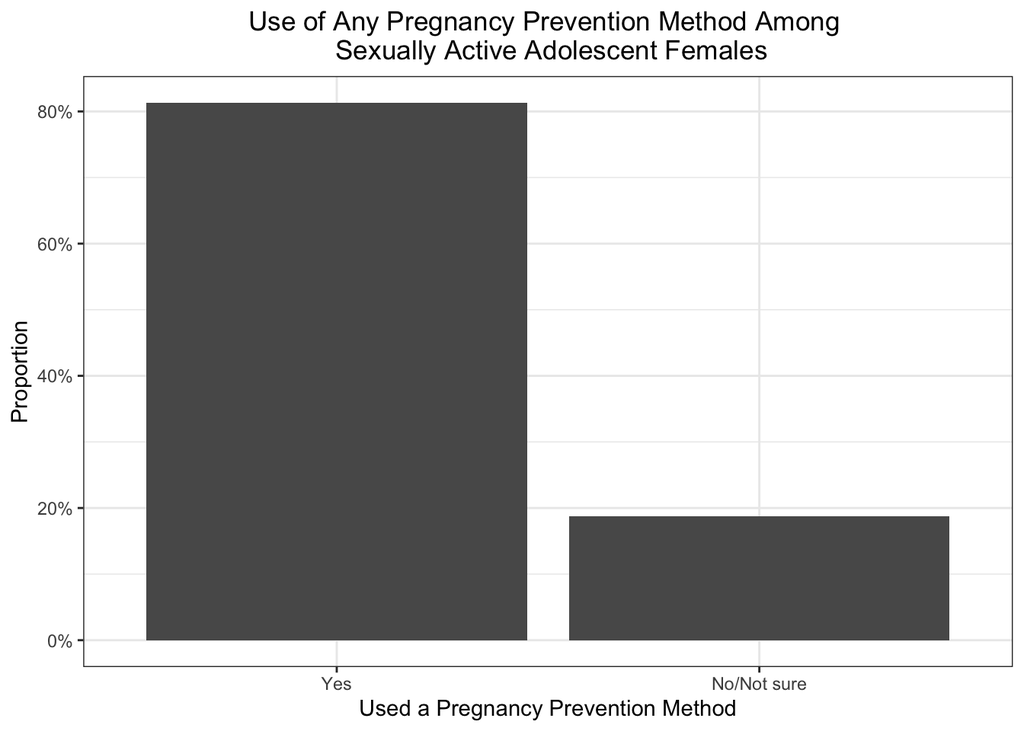

```r
plot1.all
```

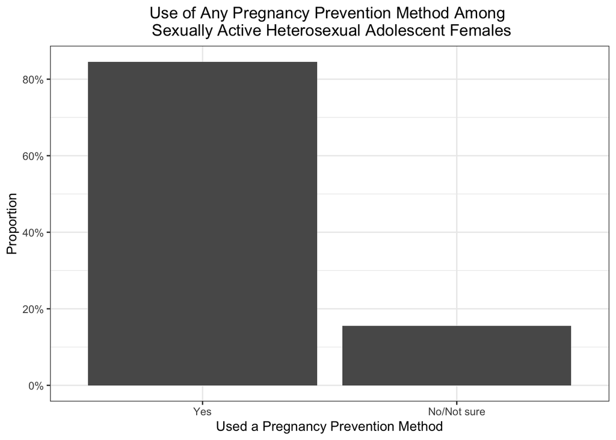

```r
plot1.het
```

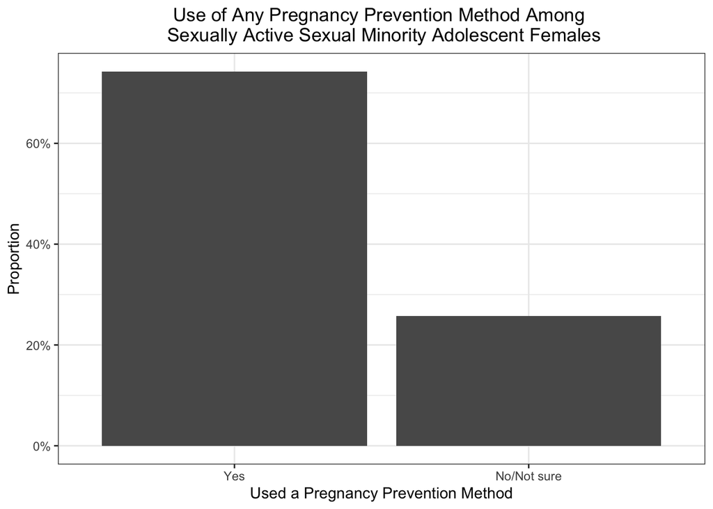

```r
plot1.sm
```

### 4.3 Figure 2 - Type of Pregnancy Prevention Method by Sexual Orientation

> Condoms were the most popular pregnancy prevention regardless of sexual minority status, followed by birth control pills. Use of no birth control and withdrawal were more prevalent among sexual minority respondents.

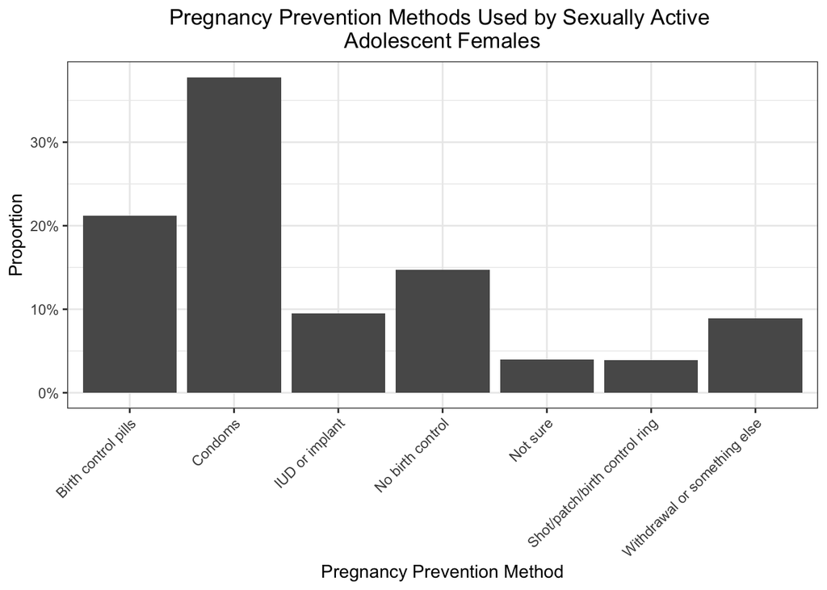

```r
plot2.all
```

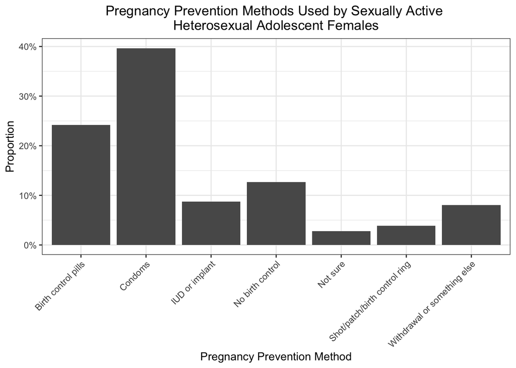

```r
plot2.het
```

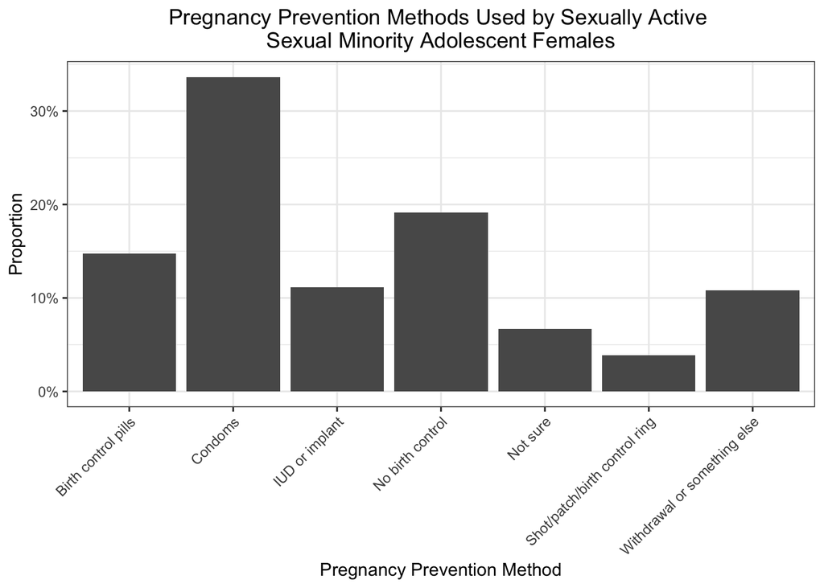

```r
plot2.sm
```

### 4.4 Logistic Regression Models

1. The first command for each model provides summary output for the logistic regression model and uses the following syntax: `summary(logreg.modelname)`
2. The second command converts the logits (i.e., log odds) to odds ratios to make the results easier to interpret and uses the following syntax: `exp(coef(logreg.modelname))`

#### 4.4.1 Unadjusted Model

> Sexual minorities have almost twice the odds of NOT using any pregnancy prevention method compared to heterosexuals.

```r
summary(logreg.unadj)
```

```
Call:
svyglm(formula = qn63 ~ sex.orientation, design = yrbs.female.logreg.svy,
    family = quasibinomial())

Survey design:
svydesign(id = ~PSU, weight = ~weight, strata = ~stratum, data = yrbs.female.logreg,
    nest = TRUE)

Coefficients:
                               Estimate Std. Error t value Pr(>|t|)
(Intercept)                     -1.7180     0.1503 -11.431 3.41e-13 ***
sex.orientationSexual Minority   0.6429     0.2643   2.433   0.0204 *
---
Signif. codes:  0 '***' 0.001 '**' 0.01 '*' 0.05 '.' 0.1 ' ' 1

(Dispersion parameter for quasibinomial family taken to be 1.005741)

Number of Fisher Scoring iterations: 4
```

```r
exp(coef(logreg.unadj))
```

```
                   (Intercept) sex.orientationSexual Minority
                     0.1794304                      1.9020208
```

#### 4.4.2 Model Adjusted for Demographics

> Sexual minorities have 1.77 times the odds of not using any pregnancy prevention method compared to heterosexuals. Compared to 9th graders, 11th and 12th graders had lower odds of not using a pregnancy prevention method. Compared to whites, Black/African American (OR=2.25) and Hispanic/Latino (OR=2.21) adolescents had greater odds of not using any pregnancy prevention method.

```r
summary(logreg.demo)
```

```
Call:
svyglm(formula = qn63 ~ sex.orientation + grade.factor + race.factor,
    design = yrbs.female.logreg.svy, family = quasibinomial())

Survey design:
svydesign(id = ~PSU, weight = ~weight, strata = ~stratum, data = yrbs.female.logreg,
    nest = TRUE)

Coefficients:
                                  Estimate Std. Error t value Pr(>|t|)
(Intercept)                        -1.4561     0.2093  -6.957 1.45e-07 ***
sex.orientationSexual Minority      0.5701     0.2493   2.287 0.029988 *
grade.factor10th                   -0.3091     0.2073  -1.491 0.147193
grade.factor11th                   -0.6961     0.2166  -3.213 0.003294 **
grade.factor12th                   -0.9890     0.2265  -4.366 0.000156 ***
race.factorBlack/African American   0.8099     0.2603   3.112 0.004251 **
race.factorHispanic/Latino          0.7951     0.2626   3.028 0.005240 **
race.factorOther                    0.5594     0.2738   2.044 0.050511 .
---
Signif. codes:  0 '***' 0.001 '**' 0.01 '*' 0.05 '.' 0.1 ' ' 1

(Dispersion parameter for quasibinomial family taken to be 0.9952561)

Number of Fisher Scoring iterations: 4
```

```r
exp(coef(logreg.demo))
```

```
                      (Intercept)    sex.orientationSexual Minority
                        0.2331393                         1.7683662
                 grade.factor10th                  grade.factor11th
                        0.7341439                         0.4985448
                 grade.factor12th race.factorBlack/African American
                        0.3719337                         2.2477933
       race.factorHispanic/Latino                  race.factorOther
                        2.2147661                         1.7496800
```

#### 4.4.3 Model Adjusted for Sex-related Factors

> Those who were 14 or older the first time they had sex had lower odds of not using a pregnancy prevention method than those who were younger than 14 when they first had sex.

```r
summary(logreg.sex)
```

```
Call:
svyglm(formula = qn63 ~ sex.orientation + qn58 + q64 + qn59 +
    qn60, design = yrbs.female.logreg.svy, family = quasibinomial())

Survey design:
svydesign(id = ~PSU, weight = ~weight, strata = ~stratum, data = yrbs.female.logreg,
    nest = TRUE)

Coefficients:
                               Estimate Std. Error t value Pr(>|t|)
(Intercept)                    -0.67678    0.45845  -1.476    0.150
sex.orientationSexual Minority  0.21993    0.40623   0.541    0.592
qn5814+                        -1.08486    0.16879  -6.427 4.25e-07 ***
q64Males                       -0.40100    0.36072  -1.112    0.275
qn590-3                         0.36385    0.28876   1.260    0.217
qn600                          -0.07471    0.29414  -0.254    0.801
---
Signif. codes:  0 '***' 0.001 '**' 0.01 '*' 0.05 '.' 0.1 ' ' 1

(Dispersion parameter for quasibinomial family taken to be 1.008523)

Number of Fisher Scoring iterations: 4
```

```r
exp(coef(logreg.sex))
```

```
                   (Intercept) sex.orientationSexual Minority
                     0.5082502                      1.2459843
                       qn5814+                       q64Males
                     0.3379495                      0.6696468
                       qn590-3                          qn600
                     1.4388575                      0.9280169
```

#### 4.4.4 Model Adjusted for Sexual Health Monitoring

> Sexual minorities have 1.95 times the odds of not using any pregnancy prevention method compared to heterosexuals.

```r
summary(logreg.sexhealth)
```

```
Call:
svyglm(formula = qn63 ~ sex.orientation + qn82 + qn83, design = yrbs.female.logreg.svy,
    family = quasibinomial())

Survey design:
svydesign(id = ~PSU, weight = ~weight, strata = ~stratum, data = yrbs.female.logreg,
    nest = TRUE)

Coefficients:
                               Estimate Std. Error t value Pr(>|t|)
(Intercept)                    -2.02677    0.26747  -7.577 2.97e-08 ***
sex.orientationSexual Minority  0.66927    0.28741   2.329   0.0273 *
qn82No/Not sure                -0.01497    0.28237  -0.053   0.9581
qn83No/Not sure                 0.40211    0.32902   1.222   0.2318
---
Signif. codes:  0 '***' 0.001 '**' 0.01 '*' 0.05 '.' 0.1 ' ' 1

(Dispersion parameter for quasibinomial family taken to be 1.017803)

Number of Fisher Scoring iterations: 4
```

```r
exp(coef(logreg.sexhealth))
```

```
                   (Intercept) sex.orientationSexual Minority
                     0.1317609                      1.9528017
               qn82No/Not sure                qn83No/Not sure
                     0.9851374                      1.4949780
```

#### 4.4.5 Model Adjusted for All Variables

> The only significant characteristics associated with not using any pregnancy prevention method were: being in 12th grade (OR=0.50), Black/African American (OR=2.52), Hispanic/Latino (OR=2.10), and having sex the first time at age 14 or older (OR=0.41).

```r
summary(logreg.all)
```

```
Call:
svyglm(formula = qn63 ~ sex.orientation + grade.factor + race.factor +
    qn58 + q64 + qn59 + q60 + qn82 + qn83, design = yrbs.female.logreg.svy,
    family = quasibinomial())

Survey design:
svydesign(id = ~PSU, weight = ~weight, strata = ~stratum, data = yrbs.female.logreg,
    nest = TRUE)

Coefficients:
                                  Estimate Std. Error t value Pr(>|t|)
(Intercept)                       -1.11536    0.52398  -2.129 0.052984 .
sex.orientationSexual Minority     0.22678    0.44863   0.505 0.621674
grade.factor10th                  -0.12682    0.20758  -0.611 0.551753
grade.factor11th                  -0.41765    0.21750  -1.920 0.077036 .
grade.factor12th                  -0.69166    0.20778  -3.329 0.005438 **
race.factorBlack/African American  0.92230    0.22921   4.024 0.001446 **
race.factorHispanic/Latino         0.74172    0.27541   2.693 0.018432 *
race.factorOther                   0.42642    0.35938   1.187 0.256640
qn5814+                           -0.88864    0.19787  -4.491 0.000607 ***
q64Males                          -0.40706    0.39318  -1.035 0.319398
qn590-3                            0.29651    0.34111   0.869 0.400469
q602 people                        0.31670    0.29718   1.066 0.305961
q603 people                        1.09582    0.70760   1.549 0.145460
q604 people                       -1.00138    1.14192  -0.877 0.396444
q605 people                        0.45277    1.65528   0.274 0.788743
q606 or more people                2.68094    1.33934   2.002 0.066639 .
q60None during past 3 months      -0.04015    0.36878  -0.109 0.914964
qn82No/Not sure                   -0.02667    0.27290  -0.098 0.923641
qn83No/Not sure                    0.42473    0.32988   1.288 0.220360
---
Signif. codes:  0 '***' 0.001 '**' 0.01 '*' 0.05 '.' 0.1 ' ' 1

(Dispersion parameter for quasibinomial family taken to be 1.01765)

Number of Fisher Scoring iterations: 5
```

```r
exp(coef(logreg.all))
```

```
                      (Intercept)    sex.orientationSexual Minority
                        0.3277986                         1.2545524
                 grade.factor10th                  grade.factor11th
                        0.8808902                         0.6585927
                 grade.factor12th race.factorBlack/African American
                        0.5007428                         2.5150691
       race.factorHispanic/Latino                  race.factorOther
                        2.0995415                         1.5317677
                          qn5814+                          q64Males
                        0.4112154                         0.6656029
                          qn590-3                       q602 people
                        1.3451609                         1.3725931
                      q603 people                       q604 people
                        2.9916460                         0.3673732
                      q605 people               q606 or more people
                        1.5726621                        14.5987832
     q60None during past 3 months                   qn82No/Not sure
                        0.9606441                         0.9736832
                  qn83No/Not sure
                        1.5291790
```

## 5 Conclusion

This study showed that, while most sexually-active female adolescents used a pregnancy prevention method during their most recent sexual encounter with an opposite-sex partner, the prevalence of contraceptive use was lower among sexual minorities. Additional correlates of pregnancy prevention included grade level, race, and age when a respondent first had sex. These findings are important to consider when crafting public health messages and interventions aimed at reducing unintended teenage pregnancy, which ought to be culturally-competent and tailored to the appropriate target audience(s). Another important result was the finding that condoms and birth control pills are the most frequently-used pregnancy prevention methods. While superior to no birth control at all, these contraception methods are notably prone to user error. This may be due to a lack of other accessible contraceptive options for adolescents, which makes increasing access to more efficacious options such as long-acting reversible contraception (e.g., IUDs, implants) of public health import. This is particularly relevant in the post-Roe era in which abortion access is limited, especially for adolescents.

This analysis has limitations. First, in order to ensure consistency of the exposure (i.e., sexual minority status), only one year of YRBS data was used. Further analyses should strive to harmonize data across survey years - while ensuring accuracy - to increase the sample size and potentially examine how contraception preferences have changed (or not) over time. Increased sample size would be especially useful given that the majority of respondents reported never having sex. An additional limitation inherent to cross-sectional analyses is the inability to establish causation between the study exposure and outcome. The item for sex only included “male” and “female” response options which excludes intersex people, potentially leading to misclassification of who is able to become pregnant. Lastly, YRBS does not include any items related to sexual education receipt or type, which likely plays an important role in the use of a pregnancy prevention method with an opposite-sex partner.

## 6 References

1. Trends in Teen Pregnancy and Childbearing | HHS Office of Population Affairs. Accessed November 9, 2023. https://opa.hhs.gov/adolescent-health/reproductive-health-and-teen-pregnancy/trends-teen-pregnancy-and-childbearing
2. About Healthy People 2030 - Healthy People 2030 | health.gov. Accessed November 9, 2023. https://health.gov/healthypeople/about
3. Increase the proportion of adolescent females who used effective birth control the last time they had sex — FP‑05 - Healthy People 2030 | health.gov. Accessed November 9, 2023. https://health.gov/healthypeople/objectives-and-data/browse-objectives/family-planning/increase-proportion-adolescent-females-who-used-effective-birth-control-last-time-they-had-sex-fp-05
4. Adolescents - Healthy People 2030 | health.gov. Accessed November 9, 2023. https://health.gov/healthypeople/objectives-and-data/browse-objectives/adolescents
5. Hofferth SL, Hayes CD, eds. *Risking the Future: Adolescent Sexuality, Pregnancy, and Childbearing, Volume II: Working Papers and Statistical Appendices*.; 1987. doi:10.17226/946
6. Martin JA, Hamilton BE, Osterman MJK, Driscoll AK, Drake P. Births: Final Data for 2016. *Natl Vital Stat Rep Cent Dis Control Prev Natl Cent Health Stat Natl Vital Stat Syst*. 2018;67(1):1-55.
7. Saewyc EM, Poon CS, Homma Y, Skay CL. Stigma management? The links between enacted stigma and teen pregnancy trends among gay, lesbian, and bisexual students in British Columbia. *Can J Hum Sex*. 2008;17(3):123-139.
8. Lindley LL, Walsemann KM. Sexual Orientation and Risk of Pregnancy Among New York City High-School Students. *Am J Public Health*. 2015;105(7):1379-1386. doi:10.2105/AJPH.2015.302553
9. Goldberg SK, Reese BM, Halpern CT. Teen Pregnancy Among Sexual Minority Women: Results From the National Longitudinal Study of Adolescent to Adult Health. *J Adolesc Health Off Publ Soc Adolesc Med*. 2016;59(4):429-437. doi:10.1016/j.jadohealth.2016.05.009
10. Charlton BM, Corliss HL, Missmer SA, Rosario M, Spiegelman D, Austin SB. Sexual orientation differences in teen pregnancy and hormonal contraceptive use: an examination across 2 generations. *Am J Obstet Gynecol*. 2013;209(3):204.e1-8. doi:10.1016/j.ajog.2013.06.036